# 23_clustering

### [clustering](https://scikit-learn.org/stable/modules/clustering.html)

- Grouping algorithms for unlabeled data.
- Scikit-Learn clustering classes return a `labels_` attribute after learning the data.
- Each method accepts a matrix `(#samples, #features)` as inputs - they can be obtained from feature_extraction classes.
- **Affinity Propagation**, **Spectral Clustering** & **DBSCAN** also accept *similarity matrices* `(#samples, #samples)` as inputs. they can be obtained from pairwise functions.

### [Kmeans](https://scikit-learn.org/stable/modules/generated/sklearn.cluster.KMeans.html#sklearn.cluster.KMeans), aka Lloyd's Algorithm

- Kmeans clusters data into $n$ (this is specified) groups of *equal variance*.
- It minimizes **inertia** (aka within-cluster sum-of-squares), $\sum_{i=0}^{n}\min_{\mu_j \in C}(||x_i - \mu_j||^2)$, to divide $N$ samples, into $K$ clusters, each described by the mean ($u_j$) of the cluster's samples.
- Inertia is a measure of a cluster's "internal coherenence".
  - It assumes clusters are convex & [isotropic](https://en.wikipedia.org/wiki/Isotropy), which isn't always true. It responds poorly to elongated clusters or manifolds with irregular shapes.
  - It is not a normalized metric and is distorted by high-dimension data. Consider using dimensionality reduction, such as **PCA** prior to use.
- Kmeans uses Cython & OpenMP to process 256-sample "chunks" in parallel to reduce memory usage.

### [Example: Kmeans assumptions vs performance](https://scikit-learn.org/stable/auto_examples/cluster/plot_kmeans_assumptions.html)

- Plots 1-3: data does not match some Kmeans assumptions - resulting in erroneous clusters.
- Plot 4: Kmeans returns intuitive results, despite uneven blob sizes.

```python
import numpy as np
import matplotlib.pyplot as plt
from sklearn.cluster import KMeans
from sklearn.datasets import make_blobs
```

```python
# Incorrect number of clusters
n, rndm = 1500, 170
X, y = make_blobs(n_samples=n, random_state=rndm)
y_pred1 = KMeans(n_clusters=2, random_state=rndm).fit_predict(X)
```

```python
# Anisotropicly distributed data
transformation = [[0.60834549, -0.63667341], [-0.40887718, 0.85253229]]
X_aniso = np.dot(X, transformation)
y_pred2 = KMeans(n_clusters=3, random_state=rndm).fit_predict(X_aniso)
```

```python
# Different variance
X_varied, y_varied = make_blobs(n_samples=n,
                                cluster_std=[1.0, 2.5, 0.5],
                                random_state=rndm)
y_pred3 = KMeans(n_clusters=3, random_state=rndm).fit_predict(X_varied)
```

```python
# Unevenly sized blobs
X_filtered = np.vstack((X[y == 0][:500],
                        X[y == 1][:100],
                        X[y == 2][:10]))
y_pred4 = KMeans(n_clusters=3, random_state=rndm).fit_predict(X_filtered)
```

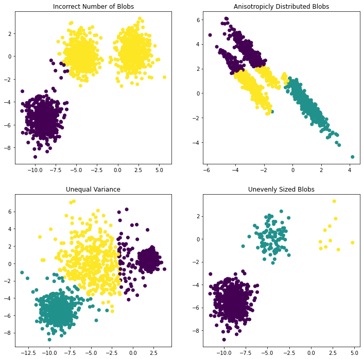

```python
plt.figure(figsize=(12, 12))

plt.subplot(221)
plt.scatter(X[:, 0], X[:, 1], c=y_pred1)
plt.title("Incorrect Number of Blobs")

plt.subplot(222)
plt.scatter(X_aniso[:, 0], X_aniso[:, 1], c=y_pred2)
plt.title("Anisotropicly Distributed Blobs")

plt.subplot(223)
plt.scatter(X_varied[:, 0], X_varied[:, 1], c=y_pred3)
plt.title("Unequal Variance")

plt.subplot(224)
plt.scatter(X_filtered[:, 0], X_filtered[:, 1], c=y_pred4)
plt.title("Unevenly Sized Blobs")

plt.show()
```

### [Example: Kmeans on digits data - Voronoi diagram](https://scikit-learn.org/stable/auto_examples/cluster/plot_kmeans_digits.html)

- Given enough time, Kmeans always converges, but possibly to a local minimum. This is highly dependent on *initial centroid values*.
- `init="k-means++"` initializes the centroids to more distant from each other, leading to better results than by random initialization.
- `sample_weight` enables sample weighting. A sample with weight=2 is equivalent to adding a duplicate of that sample to the dataset.

```python
import numpy as np
from sklearn.datasets import load_digits
from time import time
from sklearn import metrics
from sklearn.pipeline import make_pipeline
from sklearn.preprocessing import StandardScaler
from sklearn.cluster import KMeans as KM
from sklearn.decomposition import PCA
import matplotlib.pyplot as plt
```

```python
data, labels = load_digits(return_X_y=True)
(samples, features), digits = data.shape, np.unique(labels).size
```

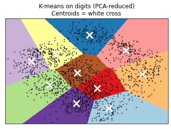

```python
import matplotlib.pyplot as plt

# PCA reduces #dims from 64 to 2
reduced_data = PCA(n_components=2).fit_transform(data)
kmeans = KMeans(init="k-means++", n_clusters=digits, n_init=4)
kmeans.fit(reduced_data)

# Mesh step size
h = .02

# Plot the decision boundary. For that, we will assign a color to each
x_min, x_max = reduced_data[:, 0].min() - 1, reduced_data[:, 0].max() + 1
y_min, y_max = reduced_data[:, 1].min() - 1, reduced_data[:, 1].max() + 1
xx, yy = np.meshgrid(np.arange(x_min, x_max, h), np.arange(y_min, y_max, h))

# Obtain labels for each point in mesh. Use last trained model.
Z = kmeans.predict(np.c_[xx.ravel(), yy.ravel()])

# Put the result into a color plot
Z = Z.reshape(xx.shape); plt.figure(1); plt.clf()

plt.imshow(Z, interpolation="nearest",
           extent=(xx.min(), xx.max(), yy.min(), yy.max()),
           cmap=plt.cm.Paired, aspect="auto", origin="lower")

plt.plot(reduced_data[:, 0],
         reduced_data[:, 1], 'k.', markersize=2)

centroids = kmeans.cluster_centers_

plt.scatter(centroids[:, 0],
            centroids[:, 1],
            marker="x", s=169, linewidths=3, color="w", zorder=10)

plt.title("K-means on digits (PCA-reduced)\n" "Centroids = white cross")
plt.xlim(x_min, x_max)
plt.ylim(y_min, y_max)
plt.xticks(()); plt.yticks(()); plt.show()
```

### [Kmeans (minibatch)](https://scikit-learn.org/stable/modules/generated/sklearn.cluster.MiniBatchKMeans.html#sklearn.cluster.MiniBatchKMeans)

- Uses *randomly sampled subsets* of the dataset during fit to reduce computation time.
- In general minibatch Kmeans performs only slightly worse than the standard implementation.
- The centroids are updated on a per-sample basis with *the streaming average of the sample and all previous samples assigned to the centroid*.

### [Example: Kmeans minibatch vs std performance](https://scikit-learn.org/stable/auto_examples/cluster/plot_mini_batch_kmeans.html)

- Also plot the points that are *labeled differently* between the two.

```python
import time
import numpy as np
import matplotlib.pyplot as plt
from sklearn.cluster import MiniBatchKMeans as KMMB, KMeans as KM
from sklearn.metrics.pairwise import pairwise_distances_argmin as PDA
from sklearn.datasets import make_blobs
```

```python
np.random.seed(0)
batch_size = 45
centers = [[1, 1], [-1, -1], [1, -1]]
n_clusters = len(centers)
X, labels_true = make_blobs(
    n_samples=3000,
    centers=centers,
    cluster_std=0.7)

k_means = KM(  init='k-means++', n_clusters=3, n_init=10)
mbk     = KMMB(init='k-means++', n_clusters=3, batch_size=batch_size,
               n_init=10, max_no_improvement=10, verbose=0)

t0 = time.time(); k_means.fit(X); t_batch = time.time() - t0
t0 = time.time();     mbk.fit(X); t_mini_batch = time.time() - t0
```

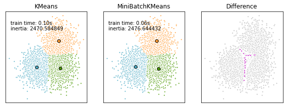

```python
fig = plt.figure(figsize=(8, 3))
fig.subplots_adjust(left=0.02, right=0.98, bottom=0.05, top=0.9)
colors = ['#4EACC5', '#FF9C34', '#4E9A06']

# We want to have the same colors for the same cluster from the
# MiniBatchKMeans and the KMeans algorithm. Let's pair the cluster centers per
# closest one.
k_means_cluster_centers   = k_means.cluster_centers_
order                     = PDA(k_means.cluster_centers_,
                                mbk.cluster_centers_)
mbk_means_cluster_centers = mbk.cluster_centers_[order]
k_means_labels            = PDA(X, k_means_cluster_centers)
mbk_means_labels          = PDA(X, mbk_means_cluster_centers)

# KMeans
ax = fig.add_subplot(1, 3, 1)
for k, col in zip(range(n_clusters), colors):
    my_members = k_means_labels == k
    cluster_center = k_means_cluster_centers[k]
    ax.plot(X[my_members, 0],
            X[my_members, 1], 'w',
            markerfacecolor=col,
            marker='.')
    ax.plot(cluster_center[0],
            cluster_center[1], 'o',
            markerfacecolor=col,
            markeredgecolor='k', markersize=6)

ax.set_title('KMeans'); ax.set_xticks(()); ax.set_yticks(())

plt.text(-3.5, 1.8,  'train time: %.2fs\ninertia: %f' % (
    t_batch, k_means.inertia_))

# MiniBatchKMeans
ax = fig.add_subplot(1, 3, 2)
for k, col in zip(range(n_clusters), colors):
    my_members = mbk_means_labels == k
    cluster_center = mbk_means_cluster_centers[k]
    ax.plot(X[my_members, 0],
            X[my_members, 1], 'w',
            markerfacecolor=col, marker='.')
    ax.plot(cluster_center[0],
            cluster_center[1], 'o',
            markerfacecolor=col,
            markeredgecolor='k', markersize=6)

ax.set_title('MiniBatchKMeans'); ax.set_xticks(()); ax.set_yticks(())

plt.text(-3.5, 1.8, 'train time: %.2fs\ninertia: %f' %
         (t_mini_batch, mbk.inertia_))

# Initialise the different array to all False
different = (mbk_means_labels == 4)
ax = fig.add_subplot(1, 3, 3)

for k in range(n_clusters):
    different += ((k_means_labels == k) != (mbk_means_labels == k))

identic = np.logical_not(different)
ax.plot(X[identic, 0], X[identic, 1], 'w',
        markerfacecolor='#bbbbbb', marker='.')
ax.plot(X[different, 0], X[different, 1], 'w',
        markerfacecolor='m', marker='.')

ax.set_title('Difference'); ax.set_xticks(()); ax.set_yticks(())
plt.show()
```

### [Affinity Propagation](https://scikit-learn.org/stable/modules/generated/sklearn.cluster.AffinityPropagation.html#sklearn.cluster.AffinityPropagation)

- Creates clusters by *sending messages between sample pairs.*
- Dataset is then described using *"exemplars"* (samples ID'd as being the *most representative of other samples*.
- The messages encode the ability of one sample to be an exemplar of another.
- This iterates until convergence (when final exemplars are chosen for the clusters).
- AP chooses the #clusters on the data (not a given number). The key parameters are `preference` (how many exemplars) and `damping factor` (helps avoid message oscillation).
- Main drawbacks: time complexity of $O(N^2T)$ & memory complexity of $O(N^2)$ ($N$ = #samples, $T$ = #iterations before convergence). More appropriate for smaller datasets.

```python
from sklearn.cluster import AffinityPropagation as AP
from sklearn import metrics
from sklearn.datasets import make_blobs
import matplotlib.pyplot as plt
from itertools import cycle
```

```python
centers = [[1, 1], [-1, -1], [1, -1]]
X, labels_true = make_blobs(n_samples=300,
                            centers=centers,
                            cluster_std=0.5,
                            random_state=None)

af                      = AP(preference=-50).fit(X)
cluster_centers_indices = af.cluster_centers_indices_
labels                  = af.labels_
n_clusters_             = len(cluster_centers_indices)
```

```python
# metrics
print('Estimated #clusters: %d' % n_clusters_)
print("Homogeneity: %0.3f" %
      metrics.homogeneity_score(labels_true, labels))
print("Completeness: %0.3f" %
      metrics.completeness_score(labels_true, labels))
print("V-measure: %0.3f" %
      metrics.v_measure_score(labels_true, labels))
print("Adjusted Rand Index: %0.3f"
      % metrics.adjusted_rand_score(labels_true, labels))
print("Adjusted Mutual Information: %0.3f"
      % metrics.adjusted_mutual_info_score(labels_true, labels))
print("Silhouette Coefficient: %0.3f"
      % metrics.silhouette_score(X, labels, metric='sqeuclidean'))
```

```
Estimated #clusters: 3
Homogeneity: 0.896
Completeness: 0.897
V-measure: 0.897
Adjusted Rand Index: 0.922
Adjusted Mutual Information: 0.896
Silhouette Coefficient: 0.766
```

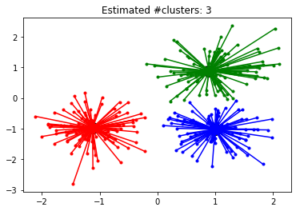

```python
plt.close('all')
plt.figure(1)
plt.clf()

colors = cycle('bgrcmykbgrcmykbgrcmykbgrcmyk')
for k, col in zip(range(n_clusters_), colors):
    class_members = labels == k
    cluster_center = X[cluster_centers_indices[k]]
    plt.plot(X[class_members, 0],
             X[class_members, 1], col + '.')
    plt.plot(cluster_center[0],
             cluster_center[1],
             'o', markerfacecolor=col,
             markeredgecolor='k', markersize=14)
    for x in X[class_members]:
        plt.plot([cluster_center[0], x[0]],
                 [cluster_center[1], x[1]], col)

plt.title('Estimated #clusters: %d' % n_clusters_)
plt.show()
```

### [Example: Affinity Propagation - Stock Market Visualization](https://scikit-learn.org/stable/auto_examples/applications/plot_stock_market.html#sphx-glr-auto-examples-applications-plot-stock-market-py)

- Use a *sparse inverse covariance estimate* to find quotes conditionally correlated on others. It will display *the strength* of the graph edges.
- Use *affinity propagation* to group similar quotes.
- Use *manifold learning* to find a 2D embedding for visualization.

```python
import sys
import numpy as np
import matplotlib.pyplot as plt
from matplotlib.collections import LineCollection
import pandas as pd
from sklearn import cluster, covariance, manifold
```

```python
symbol_dict = {
    'TOT': 'Total',    'XOM': 'Exxon',    'CVX': 'Chevron',    'COP': 'ConocoPhillips',
    'VLO': 'Valero Energy',    'MSFT': 'Microsoft',    'IBM': 'IBM',
    'TWX': 'Time Warner',    'CMCSA': 'Comcast',    'CVC': 'Cablevision',
    'YHOO': 'Yahoo',    'DELL': 'Dell',    'HPQ': 'HP',    'AMZN': 'Amazon',
    'TM': 'Toyota',    'CAJ': 'Canon',    'SNE': 'Sony',    'F': 'Ford',
    'HMC': 'Honda',    'NAV': 'Navistar',    'NOC': 'Northrop Grumman',    'BA': 'Boeing',
    'KO': 'Coca Cola',    'MMM': '3M',    'MCD': 'McDonald\'s',    'PEP': 'Pepsi',
    'K': 'Kellogg',    'UN': 'Unilever',    'MAR': 'Marriott',    'PG': 'Procter Gamble',
    'CL': 'Colgate-Palmolive',    'GE': 'General Electrics',    'WFC': 'Wells Fargo',    'JPM': 'JPMorgan Chase',
    'AIG': 'AIG',    'AXP': 'American express',    'BAC': 'Bank of America',    'GS': 'Goldman Sachs',
    'AAPL': 'Apple',    'SAP': 'SAP',    'CSCO': 'Cisco',    'TXN': 'Texas Instruments',
    'XRX': 'Xerox',    'WMT': 'Wal-Mart',    'HD': 'Home Depot',    'GSK': 'GlaxoSmithKline',
    'PFE': 'Pfizer',    'SNY': 'Sanofi-Aventis',    'NVS': 'Novartis',    'KMB': 'Kimberly-Clark',
    'R': 'Ryder',    'GD': 'General Dynamics',    'RTN': 'Raytheon',    'CVS': 'CVS',
    'CAT': 'Caterpillar',    'DD': 'DuPont de Nemours'}
```

```python
symbols, names = np.array(sorted(symbol_dict.items())).T

quotes = []

for symbol in symbols:
    print('Fetching quote history for %r' % symbol, file=sys.stderr)
    url = ('https://raw.githubusercontent.com/scikit-learn/examples-data/'
           'master/financial-data/{}.csv')
    quotes.append(pd.read_csv(url.format(symbol)))

close_prices = np.vstack([q['close'] for q in quotes])
open_prices  = np.vstack([q['open'] for q in quotes])
variation    = close_prices - open_prices
edge_model   = covariance.GraphicalLassoCV()

# standardize time series: using correlations rather than covariance
# is more efficient for structure recovery
X = variation.copy().T
X /= X.std(axis=0)
edge_model.fit(X)
```

[output not shown]

```
GraphicalLassoCV()
```

```python
_, labels = cluster.affinity_propagation(edge_model.covariance_, random_state=0)
n_labels  = labels.max()
for i in range(n_labels + 1):
    print('Cluster %i: %s' % ((i + 1), ', '.join(names[labels == i])))

# #############################################################################
# Find low-D embedding for visualization
# We use a dense eigen_solver to achieve reproducibility (arpack is
# initiated with random vectors that we don't control). In addition, we
# use a large number of neighbors to capture the large-scale structure.
node_position_model = manifold.LocallyLinearEmbedding(
    n_components=2, eigen_solver='dense', n_neighbors=6)
embedding = node_position_model.fit_transform(X.T).T
```

```
Cluster 1: Apple, Amazon, Yahoo
Cluster 2: Comcast, Cablevision, Time Warner
Cluster 3: ConocoPhillips, Chevron, Total, Valero Energy, Exxon
Cluster 4: Cisco, Dell, HP, IBM, Microsoft, SAP, Texas Instruments
Cluster 5: Boeing, General Dynamics, Northrop Grumman, Raytheon
Cluster 6: AIG, American express, Bank of America, Caterpillar, CVS, DuPont de Nemours, Ford, General Electrics, Goldman Sachs, Home Depot, JPMorgan Chase, Marriott, 3M, Ryder, Wells Fargo, Wal-Mart
Cluster 7: McDonald's
Cluster 8: GlaxoSmithKline, Novartis, Pfizer, Sanofi-Aventis, Unilever
Cluster 9: Kellogg, Coca Cola, Pepsi
Cluster 10: Colgate-Palmolive, Kimberly-Clark, Procter Gamble
Cluster 11: Canon, Honda, Navistar, Sony, Toyota, Xerox
```

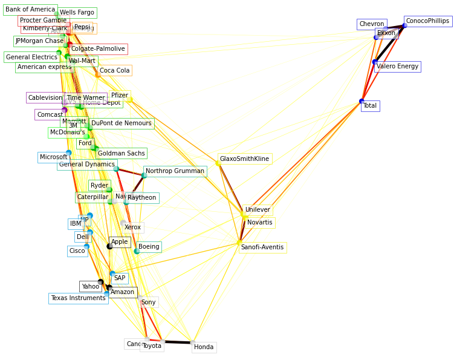

```python
plt.figure(1, facecolor='w', figsize=(10, 8))
plt.clf()
ax = plt.axes([0., 0., 1., 1.])
plt.axis('off')

# Display a graph of the partial correlations
partial_correlations = edge_model.precision_.copy()
d = 1 / np.sqrt(np.diag(partial_correlations))
partial_correlations *= d
partial_correlations *= d[:, np.newaxis]
non_zero = (np.abs(np.triu(partial_correlations, k=1)) > 0.02)

# Plot the nodes using the coordinates of our embedding
plt.scatter(embedding[0], embedding[1], s=100 * d ** 2, c=labels,
            cmap=plt.cm.nipy_spectral)

# Plot the edges
start_idx, end_idx = np.where(non_zero)
# a sequence of (*line0*, *line1*, *line2*), where::
#            linen = (x0, y0), (x1, y1), ... (xm, ym)
segments = [[embedding[:, start], embedding[:, stop]]
            for start, stop in zip(start_idx, end_idx)]
values = np.abs(partial_correlations[non_zero])
lc = LineCollection(segments,
                    zorder=0, cmap=plt.cm.hot_r,
                    norm=plt.Normalize(0, .7 * values.max()))
lc.set_array(values)
lc.set_linewidths(15 * values)
ax.add_collection(lc)

# Add a label to each node. The challenge here is that we want to
# position the labels to avoid overlap with other labels
for index, (name, label, (x, y)) in enumerate(
        zip(names, labels, embedding.T)):

    dx = x - embedding[0]
    dx[index] = 1
    dy = y - embedding[1]
    dy[index] = 1
    this_dx = dx[np.argmin(np.abs(dy))]
    this_dy = dy[np.argmin(np.abs(dx))]
    if this_dx > 0:
        horizontalalignment = 'left'
        x = x + .002
    else:
        horizontalalignment = 'right'
        x = x - .002
    if this_dy > 0:
        verticalalignment = 'bottom'
        y = y + .002
    else:
        verticalalignment = 'top'
        y = y - .002
    plt.text(x, y, name, size=10,
             horizontalalignment=horizontalalignment,
             verticalalignment=verticalalignment,
             bbox=dict(facecolor='w',
                       edgecolor=plt.cm.nipy_spectral(label / float(n_labels)),
                       alpha=.6))

plt.xlim(embedding[0].min() - .15 * embedding[0].ptp(),
         embedding[0].max() + .10 * embedding[0].ptp(),)
plt.ylim(embedding[1].min() - .03 * embedding[1].ptp(),
         embedding[1].max() + .03 * embedding[1].ptp())

plt.show()
```

### [Mean Shift](https://scikit-learn.org/stable/modules/generated/sklearn.cluster.MeanShift.html#sklearn.cluster.MeanShift)

- Looks for *blobs* in a smooth density of samples.
- Given centroid candidate $x_i$ for iteration $t$ - update the candidate using $x_i^{t+1} = m(x_i^t)$
  - $m$ = the *mean shift vector* that points to a region of *maximum point density increase*.
- `bandwidth` sets the size of region to search. It can be set manually or estimated using the `estimate_bandwidth` function.
- Limited scalability due to using *multiple nearest-neighbor searches*.

### [Example Mean Shift](https://scikit-learn.org/stable/auto_examples/cluster/plot_mean_shift.html)

```python
import numpy as np
from sklearn.cluster import MeanShift, estimate_bandwidth
from sklearn.datasets import make_blobs
```

```python
centers = [[1, 1], [-1, -1], [1, -1]]

X, _    = make_blobs(n_samples=10000,
                     centers=centers,
                     cluster_std=0.6)
bandwidth = estimate_bandwidth(X,
                               quantile=0.2,
                               n_samples=500)

ms = MeanShift(bandwidth=bandwidth,
               bin_seeding=True).fit(X)

labels          = ms.labels_
cluster_centers = ms.cluster_centers_
labels_unique   = np.unique(labels)
n_clusters_     = len(labels_unique)

print("#estimated clusters : %d" % n_clusters_)
```

```
#estimated clusters : 3
```

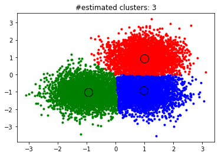

```python
import matplotlib.pyplot as plt
from itertools import cycle

plt.figure(1); plt.clf()

colors = cycle('bgrcmykbgrcmykbgrcmykbgrcmyk')
for k, col in zip(range(n_clusters_), colors):
    my_members = labels == k
    cluster_center = cluster_centers[k]
    plt.plot(X[my_members, 0],
             X[my_members, 1], col + '.')
    plt.plot(cluster_center[0],
             cluster_center[1],
             'o', markerfacecolor=col,
             markeredgecolor='k', markersize=14)
plt.title('#estimated clusters: %d' % n_clusters_)
```

### [Spectral Clustering](https://scikit-learn.org/stable/modules/generated/sklearn.cluster.SpectralClustering.html#sklearn.cluster.SpectralClustering)

- Builds a low-D embedding of the *affinity matrix* between samples, then uses *Kmeans clustering* of the eigenvectors' components.
- Especially efficient if the affinity matrix is sparse, and the `amg` solver is used for the eigenvalue computation. (requires the pyamg module.)
- Requires specifying #clusters in advance. Works well for small #clusters, not so for larger #clusters.

### [Example: Spectral clustering - image segmentation](https://scikit-learn.org/stable/auto_examples/cluster/plot_segmentation_toy.html#sphx-glr-auto-examples-cluster-plot-segmentation-toy-py)

- Task: separate circles in an image with connected circles.
- SC views this as a *normalized cuts* problem.

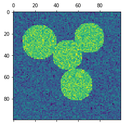

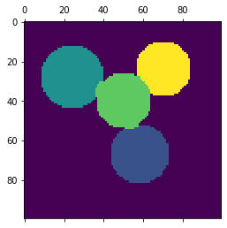

```python
import numpy as np
import matplotlib.pyplot as plt
from sklearn.feature_extraction import image
from sklearn.cluster import spectral_clustering as SC

l = 100; x, y = np.indices((l, l))

center1 = (28, 24); center2 = (40, 50)
center3 = (67, 58); center4 = (24, 70)

radius1, radius2, radius3, radius4 = 16, 14, 15, 14

circle1 = (x-center1[0]) ** 2+(y-center1[1]) ** 2 < radius1 ** 2
circle2 = (x-center2[0]) ** 2+(y-center2[1]) ** 2 < radius2 ** 2
circle3 = (x-center3[0]) ** 2+(y-center3[1]) ** 2 < radius3 ** 2
circle4 = (x-center4[0]) ** 2+(y-center4[1]) ** 2 < radius4 ** 2

img = circle1 + circle2 + circle3 + circle4

# Sse a mask that limits to the foreground.
# we are not interested in separating the objects from the background,
# but separating them one from the other.
mask = img.astype(bool)
img  = img.astype(float)
img += 1 + 0.2 * np.random.randn(*img.shape)

# Convert image to graph with value of gradient on the edges.
graph = image.img_to_graph(img, mask=mask)

# Take a decreasing function of the gradient: we take it weakly
# dependent from the gradient the segmentation is close to a voronoi
graph.data = np.exp(-graph.data / graph.data.std())

# Force the solver to be arpack, since amg is numerically
# unstable on this example
labels         = SC(graph, n_clusters=4, eigen_solver='arpack')
label_im       = np.full(mask.shape, -1.)
label_im[mask] = labels

plt.matshow(img)
plt.matshow(label_im)
```

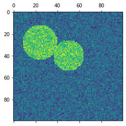

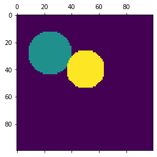

```python
img        = circle1 + circle2
mask       = img.astype(bool)
img        = img.astype(float)
img       += 1 + 0.2 * np.random.randn(*img.shape)
graph      = image.img_to_graph(img, mask=mask)
graph.data = np.exp(-graph.data / graph.data.std())
labels     = SC(graph,
                n_clusters=2, eigen_solver='arpack')
label_im   = np.full(mask.shape, -1.)
label_im[mask] = labels

plt.matshow(img)
plt.matshow(label_im)
plt.show()
```

### Example: Spectral Clustering - label assignment strategies

- `assign_labels="kmeans"` = can match fine-level details, but can be unstable & unreproduceable - especially if you don't control `random_state`
- `assign_labels="discretize"` is 100% reproduceable, but tends to produce parcels of even & geometric shape.

```python
import time
import numpy as np
from scipy.ndimage.filters import gaussian_filter as GF
import matplotlib.pyplot as plt
import skimage
from skimage.data import coins
from skimage.transform import rescale
from sklearn.feature_extraction import image
from sklearn.cluster import spectral_clustering as SC
from sklearn.utils.fixes import parse_version as PV
```

```python
# these were introduced in skimage-0.14
if PV(skimage.__version__) >= PV('0.14'):
    rescale_params = {'anti_aliasing': False,
                      'multichannel': False}
else:
    rescale_params = {}

# Load coins as NumPy array
# Resize it to 20% of the original size to speed up the processing
# Apply Gaussian filter for smoothing prior to down-scaling
# reduces aliasing artifacts.
# Convert image to graph with gradient value on the edges.
orig_coins       = coins()
smoothened_coins = GF(orig_coins, sigma=2)
rescaled_coins   = rescale(smoothened_coins,
                           0.2,
                           mode="reflect",
                           **rescale_params)
graph            = image.img_to_graph(rescaled_coins)

# Take a decreasing function of the gradient: an exponential
# Smaller beta = more independent the segmentation is from actual image.
# For beta=1, the segmentation is close to a voronoi
beta,eps   = 10, 1e-6
graph.data = np.exp(-beta*graph.data/graph.data.std()) + eps
```

```
Spectral clustering: kmeans, 6.00s
Spectral clustering: discretize, 3.79s
```

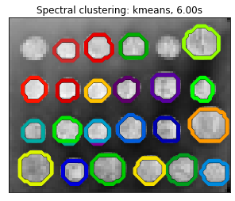

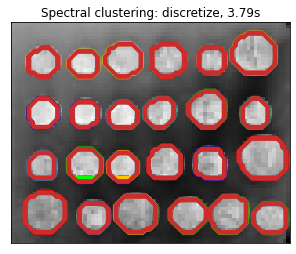

```python
# Apply spectral clustering (much faster if pyamg installed)
N_REGIONS = 25
for strategy in ('kmeans', 'discretize'):
    t0 = time.time()
    labels = SC(graph,
                n_clusters=N_REGIONS,
                assign_labels=strategy, random_state=42)
    t1 = time.time()
    labels = labels.reshape(rescaled_coins.shape)

    plt.figure(figsize=(5, 5))
    plt.imshow(rescaled_coins, cmap=plt.cm.gray)

    for l in range(N_REGIONS):
        plt.contour(labels == l,
                    colors=[plt.cm.nipy_spectral(l / float(N_REGIONS))])

    plt.xticks(()); plt.yticks(())
    title = 'Spectral clustering: %s, %.2fs' % (strategy, (t1 - t0))
    print(title)
    plt.title(title)
plt.show()
```

### [Agglomerative Clustering](https://scikit-learn.org/stable/modules/generated/sklearn.cluster.AgglomerativeClustering.html#sklearn.cluster.AgglomerativeClustering)

- Performs *hierarchical clustering*. Starts with each observation in its own cluster, then iteratively merges them together.
- The **linkage criteria** determines the merge strategy. Agglomerative clustering is a "rich get richer" algorithm - leading to uneven cluster sizes.
  - **Ward**: minimizes the *sum of squared differences* between clusters.
  - **Maximum/complete**: minimizes the *max distance* between cluster pairs.
  - **Average**: minimizes the *average distance* between cluster pairs.
  - **Single**: minimizes the distance between *closest observations* of cluster pairs. Not robust to noisy data, but computationally efficient & scalable.
- AC is *computationally expensive* when no connectivity constraints are used. (ie, it considers all possible merges at each step.) Consider using a *connectivity matrix* to improve scalability.

### [Example: Agglomerative Clustering, Linkage Performance](https://scikit-learn.org/stable/auto_examples/cluster/plot_linkage_comparison.html)

- Single linkage is fast, but susceptible to noise.
- Average & complete linkages do well on "clean" globular data, mixed results elsewhere.
- Ward linkage is best on noisy data.

```python
import time
import warnings
import numpy as np
import matplotlib.pyplot as plt
from sklearn import cluster, datasets
from sklearn.preprocessing import StandardScaler as SS
from itertools import cycle, islice
np.random.seed(0)
#from sklearn.cluster import AgglomerativeClustering as AC
```

```python
n = 1500
noisy_circles = datasets.make_circles(n_samples=n, factor=.5, noise=.05)
noisy_moons  = datasets.make_moons(   n_samples=n,            noise=.05)
blobs        = datasets.make_blobs(   n_samples=n, random_state=8)
no_structure = np.random.rand(n,2), None

# anisotropicly distributed data
X, y           = datasets.make_blobs(n_samples=n, random_state=170)
transformation = [[0.6, -0.6], [-0.4, 0.8]]
X_aniso        = np.dot(X, transformation)
aniso          = (X_aniso, y)

# blobs with varied variances
varied = datasets.make_blobs(n_samples=n,
                             cluster_std=[1.0, 2.5, 0.5],
                             random_state=170)
```

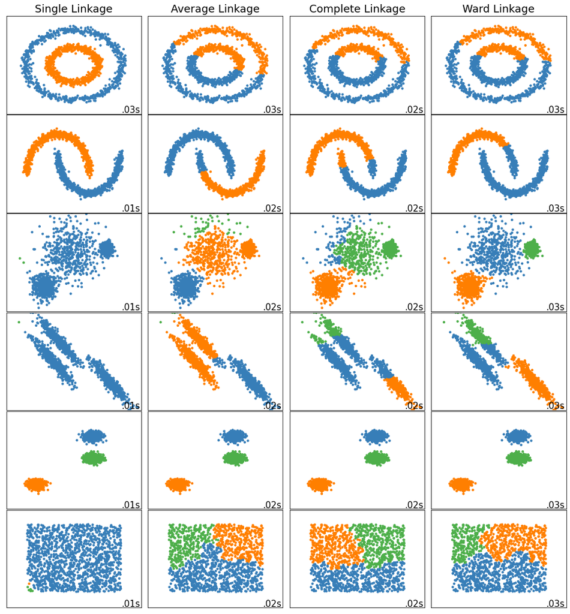

```python
plt.figure(figsize=(9 * 1.3 + 2, 14.5))
plt.subplots_adjust(left=.02, right=.98, bottom=.001, top=.96,
                    wspace=.05, hspace=.01)

plot_num = 1
default_base = {'n_neighbors': 10,
                'n_clusters': 3}

datasets = [
    (noisy_circles, {'n_clusters': 2}),
    (noisy_moons,   {'n_clusters': 2}),
    (varied,        {'n_neighbors': 2}),
    (aniso,         {'n_neighbors': 2}),
    (blobs,         {}),
    (no_structure,  {})]

for i_dataset, (dataset, algo_params) in enumerate(datasets):
    params = default_base.copy() # update params w/ dataset specifics
    params.update(algo_params)
    X, y = dataset
    X = StandardScaler().fit_transform(X) #normalize dataset

    ward     = cluster.AgglomerativeClustering(
        n_clusters=params['n_clusters'], linkage='ward')
    complete = cluster.AgglomerativeClustering(
        n_clusters=params['n_clusters'], linkage='complete')
    average  = cluster.AgglomerativeClustering(
        n_clusters=params['n_clusters'], linkage='average')
    single   = cluster.AgglomerativeClustering(
        n_clusters=params['n_clusters'], linkage='single')

    clustering_algorithms = (
        ('Single Linkage', single),
        ('Average Linkage', average),
        ('Complete Linkage', complete),
        ('Ward Linkage', ward),
    )

    for name, algorithm in clustering_algorithms:
        t0 = time.time()

        # catch warnings related to kneighbors_graph
        with warnings.catch_warnings():
            warnings.filterwarnings(
                "ignore",
                message="#connected components of the " +
                "connectivity matrix is [0-9]{1,2}" +
                " > 1. Completing it to avoid stopping the tree early.",
                category=UserWarning)
            algorithm.fit(X)

        t1 = time.time()
        if hasattr(algorithm, 'labels_'):
            y_pred = algorithm.labels_.astype(int)
        else:
            y_pred = algorithm.predict(X)

        plt.subplot(len(datasets), len(clustering_algorithms), plot_num)
        if i_dataset == 0:
            plt.title(name, size=18)

        colors = np.array(list(islice(cycle(['#377eb8', '#ff7f00', '#4daf4a',
                                             '#f781bf', '#a65628', '#984ea3',
                                             '#999999', '#e41a1c', '#dede00']),
                                      int(max(y_pred) + 1))))
        plt.scatter(X[:, 0], X[:, 1], s=10, color=colors[y_pred])

        plt.xlim(-2.5, 2.5); plt.ylim(-2.5, 2.5)
        plt.xticks(());      plt.yticks(())
        plt.text(.99, .01, ('%.2fs' % (t1 - t0)).lstrip('0'),
                 transform=plt.gca().transAxes, size=15,
                 horizontalalignment='right')
        plot_num += 1
plt.show()
```

### [Hierarchical Cluster Visualization with Dendrograms](https://scikit-learn.org/stable/auto_examples/cluster/plot_agglomerative_dendrogram.html)

```python
import numpy as np
from matplotlib import pyplot as plt
from scipy.cluster.hierarchy import dendrogram
from sklearn.datasets import load_iris
from sklearn.cluster import AgglomerativeClustering as AC
```

```python
def plot_dendrogram(model, **kwargs):
    # Create linkage matrix and then plot the dendrogram

    # create the counts of samples under each node
    counts    = np.zeros(model.children_.shape[0])
    n_samples = len(model.labels_)

    for i, merge in enumerate(model.children_):
        current_count = 0
        for child_idx in merge:
            if child_idx < n_samples:
                current_count += 1  # leaf node
            else:
                current_count += counts[child_idx - n_samples]
        counts[i] = current_count

    linkage_matrix = np.column_stack([model.children_,
                                      model.distances_,
                                      counts]).astype(float)

    dendrogram(linkage_matrix, **kwargs)


iris = load_iris(); X = iris.data

# distance_threshold=0 ensures we compute the full tree.
model = AC(distance_threshold=0,
           n_clusters=None).fit(X)
```

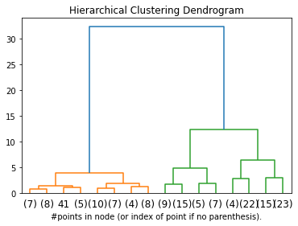

```python
plt.title('Hierarchical Clustering Dendrogram')
plot_dendrogram(model, truncate_mode='level', p=3)
plt.xlabel("#points in node (or index of point if no parenthesis).")
plt.show()
```

### Agglomerative Clustering & Connectivity Constraints

```python
import time as time
import numpy as np
import matplotlib.pyplot as plt
import mpl_toolkits.mplot3d.axes3d as p3
from sklearn.cluster import AgglomerativeClustering as AC
from sklearn.datasets import make_swiss_roll as SR
```

```
Elapsed time: 0.04s
#points: 1500
```

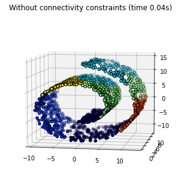

```python
# make a "thin" swiss roll
n, noise = 1500, 0.05
X, _     = SR(n, noise=noise); X[:, 1] *= .5

t0 = time.time()
ward = AC(n_clusters=6, linkage='ward').fit(X)
t1 = time.time() - t0
label = ward.labels_
print("Elapsed time: %.2fs" % t1)
print("#points: %i" % label.size)

fig = plt.figure()
ax = p3.Axes3D(fig)
ax.view_init(7, -80)
for l in np.unique(label):
    ax.scatter(X[label == l, 0],
               X[label == l, 1],
               X[label == l, 2],
               color=plt.cm.jet(float(l) / np.max(label + 1)), s=20, edgecolor='k')
plt.title('Without connectivity constraints (time %.2fs)' % t1)
```

```
Elapsed time: 0.06s
#points: 1500
```

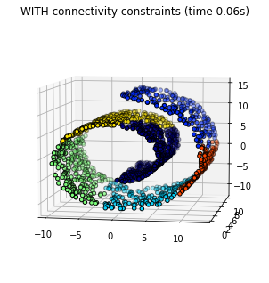

```python
# define data structure - 10 NNs
from sklearn.neighbors import kneighbors_graph as KNG
connectivity = KNG(X, n_neighbors=10, include_self=False)
t0 = time.time()
ward = AC(n_clusters=6, connectivity=connectivity, linkage='ward').fit(X)
t1 = time.time() - t0
label = ward.labels_
print("Elapsed time: %.2fs" % t1)
print("#points: %i" % label.size)

fig = plt.figure()
ax = p3.Axes3D(fig)
ax.view_init(7, -80)
for l in np.unique(label):
    ax.scatter(X[label == l, 0],
               X[label == l, 1],
               X[label == l, 2],
               color=plt.cm.jet(float(l) / np.max(label + 1)), s=20, edgecolor='k')
plt.title('WITH connectivity constraints (time %.2fs)' % t1)
plt.show()
```

### [Agglomerative Clustering and Connectivity Graphs](https://scikit-learn.org/stable/auto_examples/cluster/plot_agglomerative_clustering.html)

```python
import time
import matplotlib.pyplot as plt
import numpy as np
from sklearn.cluster import AgglomerativeClustering as AC
from sklearn.neighbors import kneighbors_graph as KNG
```

```python
np.random.seed(0)
n=1500; t=1.5*np.pi*(1+3*np.random.rand(1,n))
x,y = t*np.cos(t), t*np.sin(t)

X = np.concatenate((x,y));
X += 0.7*np.random.randn(2,n); X=X.T

# create local connectivity graph
# larger #neighbors = more homogeneous clusters, but more computation time
knn_graph = KNG(X,30,include_self=False)
```

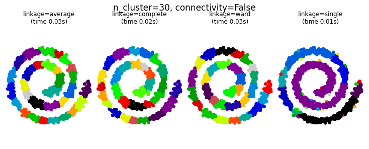

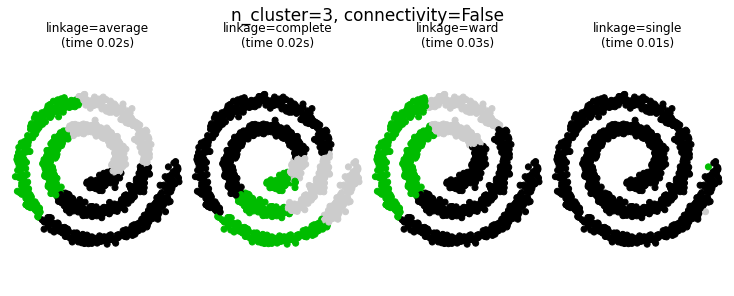

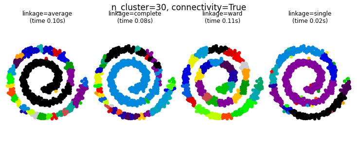

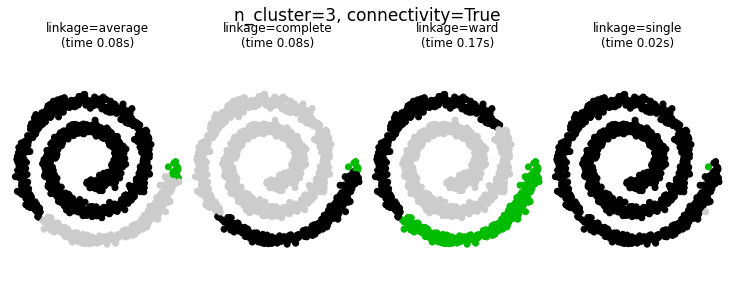

```python
for connectivity in (None, knn_graph):
    for n_clusters in (30, 3):
        plt.figure(figsize=(10, 4))
        for index, linkage in enumerate(('average',
                                         'complete',
                                         'ward',
                                         'single')):
            plt.subplot(1, 4, index+1)
            model = AC(linkage=linkage,
                       connectivity=connectivity,
                       n_clusters=n_clusters)

            t0 = time.time(); model.fit(X); t1 = time.time()-t0

            plt.scatter(X[:, 0],
                        X[:, 1], c=model.labels_, cmap=plt.cm.nipy_spectral)

            plt.title('linkage=%s\n(time %.2fs)' % (linkage, t1),
                      fontdict=dict(verticalalignment='top'))
            plt.axis('equal')
            plt.axis('off')
            plt.subplots_adjust(bottom=0, top=.83, wspace=0, left=0, right=1)
            plt.suptitle('n_cluster=%i, connectivity=%r' %
                         (n_clusters, connectivity is not None), size=17)
plt.show()
```

### [Agglomerative Clustering & Distance Metrics](https://scikit-learn.org/stable/auto_examples/cluster/plot_agglomerative_clustering_metrics.html)

- Single, average & complete linkage can be used with different distances (aka affinities), especially *Euclidean* (l2), *Manhattan* (l1), cosine, or any precomputed affinity matrix.
- l1 distance is often good for *sparse* features or noise.
- cosine distance is invariant to global scaling of the signal.
- Guideline: choose a metric that *maximizes the distance between samples in difference classes*, and *minimizes distance within each class*.

```python
import matplotlib.pyplot as plt
import numpy as np
from sklearn.cluster import AgglomerativeClustering as AC
from sklearn.metrics import pairwise_distances as PD
```

```python
np.random.seed(0)
n=2000; t = np.pi*np.linspace(0,1,n)
X,y=[],[]

def sqr(x):
    return np.sign(np.cos(x))

for i, (phi,a) in enumerate([(0.5,0.15), (0.5,0.6), (0.3,0.2)]):
    for _ in range(30):
        phase_noise = 0.01*np.random.normal()
        amplitude_noise = 0.04*np.random.normal()
        more_noise      = 1-2*np.random.rand(n)
        # make the noise sparse
        more_noise[np.abs(more_noise)<0.997]=0

        X.append(12*((a+amplitude_noise)*
                     (sqr(6*(t+phi+phase_noise)))
                    +more_noise))
        y.append(i)

X,y = np.array(X), np.array(y)

n_clusters=3; labels=("waveform 1","waveform 2","waveform 3")
```

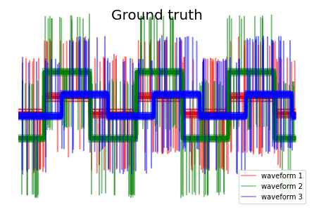

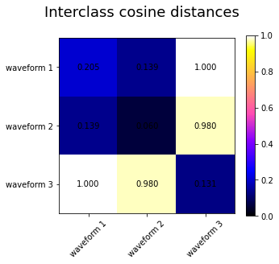

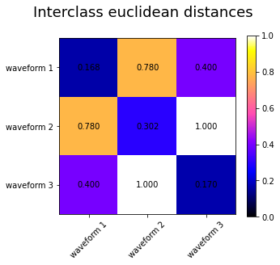

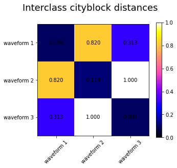

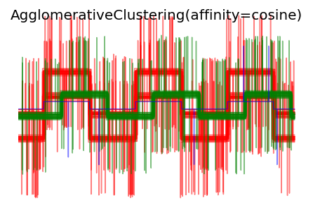

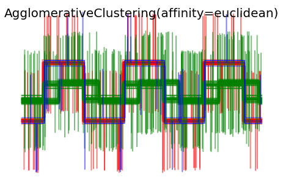

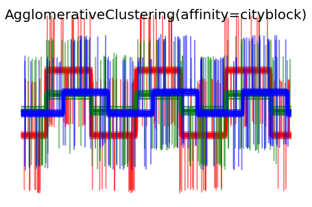

```python
plt.figure()
plt.axes([0, 0, 1, 1])
for l, c, n in zip(range(n_clusters), 'rgb',
                   labels):
    lines = plt.plot(X[y == l].T, c=c, alpha=.5)
    lines[0].set_label(n)

plt.legend(loc='best')
plt.axis('tight'); plt.axis('off'); plt.suptitle("Ground truth", size=20)

# Plot the distances
for index, metric in enumerate(["cosine", "euclidean", "cityblock"]):
    avg_dist = np.zeros((n_clusters, n_clusters))
    plt.figure(figsize=(5, 4.5))
    for i in range(n_clusters):
        for j in range(n_clusters):
            avg_dist[i, j] = PD(X[y == i],
                                X[y == j], metric=metric).mean()
    avg_dist /= avg_dist.max()

    for i in range(n_clusters):
        for j in range(n_clusters):
            plt.text(i, j, '%5.3f' % avg_dist[i, j],
                     verticalalignment='center',
                     horizontalalignment='center')

    plt.imshow(avg_dist, interpolation='nearest', cmap=plt.cm.gnuplot2,
               vmin=0)
    plt.xticks(range(n_clusters), labels, rotation=45)
    plt.yticks(range(n_clusters), labels)
    plt.colorbar()
    plt.suptitle("Interclass %s distances" % metric, size=18)
    plt.tight_layout()

# Plot clustering results
for index, metric in enumerate(["cosine", "euclidean", "cityblock"]):
    model = AC(n_clusters=n_clusters,
               linkage="average",
               affinity=metric)
    model.fit(X)
    plt.figure()
    plt.axes([0, 0, 1, 1])
    for l, c in zip(np.arange(model.n_clusters), 'rgbk'):
        plt.plot(X[model.labels_ == l].T, c=c, alpha=.5)
    plt.axis('tight')
    plt.axis('off')
    plt.suptitle("AgglomerativeClustering(affinity=%s)" % metric, size=20)


plt.show()
```

### DBSCAN

- Clusters found by DBSCAN can be *of any shape* (compared to Kmeans, which assumes convex clusters).
- `min_samples` and `eps` define density for this algorithm. `min_samples` controls the algorithm's tolerance for noise. `eps` controls the local neighborhood and usually cannot be left as a default value.
- *core samples* are samples such that there are `min_samples` within a distance of `eps`. A cluster is set of core samples that can be built by recursively taking a core sample, finding all of its neighbors that are also core samples, and so on.

```python
import numpy as np

from sklearn.cluster import DBSCAN
from sklearn import metrics
from sklearn.datasets import make_blobs
from sklearn.preprocessing import StandardScaler as SS
```

```python
centers = [[1, 1], [-1, -1], [1, -1]]
X, labels_true = make_blobs(n_samples=750,
                            centers=centers,
                            cluster_std=0.4,
                            random_state=0)

X  = SS().fit_transform(X)
db = DBSCAN(eps=0.3, min_samples=10).fit(X)

core_samples_mask = np.zeros_like(db.labels_, dtype=bool)
core_samples_mask[db.core_sample_indices_] = True
labels = db.labels_

# Number of clusters in labels, ignoring noise if present.
n_clusters_ = len(set(labels)) - (1 if -1 in labels else 0)
n_noise_    = list(labels).count(-1)
```

```python
print('Est. #clusters: %d'     % n_clusters_)
print('Est. #noise points: %d' % n_noise_)
print("Homogeneity: %0.3f"     % metrics.homogeneity_score(labels_true, labels))
print("Completeness: %0.3f"    % metrics.completeness_score(labels_true, labels))
print("V-measure: %0.3f"       % metrics.v_measure_score(labels_true, labels))
print("Adj Rand Index: %0.3f"  % metrics.adjusted_rand_score(labels_true, labels))
print("Adj Mutual Info: %0.3f" % metrics.adjusted_mutual_info_score(labels_true, labels))
print("Silhouette Coef: %0.3f" % metrics.silhouette_score(X, labels))
```

```
Est. #clusters: 3
Est. #noise points: 18
Homogeneity: 0.953
Completeness: 0.883
V-measure: 0.917
Adj Rand Index: 0.952
Adj Mutual Info: 0.916
Silhouette Coef: 0.626
```

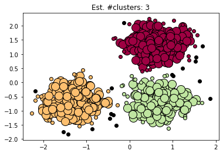

```python
import matplotlib.pyplot as plt

# Black removed and is used for noise instead.
unique_labels = set(labels)
colors = [plt.cm.Spectral(each)
          for each in np.linspace(0, 1, len(unique_labels))]

for k, col in zip(unique_labels, colors):
    if k == -1:
        col = [0, 0, 0, 1]

    class_member_mask = (labels == k)

    xy = X[class_member_mask &
           core_samples_mask]

    plt.plot(xy[:, 0],
             xy[:, 1], 'o', markerfacecolor=tuple(col),
             markeredgecolor='k', markersize=14)

    xy = X[class_member_mask &
           ~core_samples_mask]

    plt.plot(xy[:, 0],
             xy[:, 1], 'o', markerfacecolor=tuple(col),
             markeredgecolor='k', markersize=6)

plt.title('Est. #clusters: %d' % n_clusters_)
plt.show()
```

### OPTICS

- Similar to DBSCAN, and allows multiple values of `eps`.
- Builds a *reachability graph* (assigns each sample a `reachability_` distance and an `ordering_` value (spot within the cluster).
- `max_eps="inf"` tells OPTICS to run repeatedly in linear time using the `cluster_optics_dbscan` method. Shorter values result in shorter run times.
- Varying `reachability_` enables variable density extractions. Combining it with `ordering_` can be used to build a *reachability plot* (Y-axis = point density, X-axis = point ordering).

```python
from sklearn.cluster import OPTICS, cluster_optics_dbscan as CODB
import matplotlib.gridspec as gridspec
import matplotlib.pyplot as plt
import numpy as np
```

```python
np.random.seed(0)
n_points_per_cluster = 250

C1    = [-5, -2] + 0.8 * np.random.randn(n_points_per_cluster, 2)
C2    = [ 4, -1] + 0.1 * np.random.randn(n_points_per_cluster, 2)
C3    = [ 1, -2] + 0.2 * np.random.randn(n_points_per_cluster, 2)
C4    = [-2,  3] + 0.3 * np.random.randn(n_points_per_cluster, 2)
C5    = [ 3, -2] + 1.6 * np.random.randn(n_points_per_cluster, 2)
C6    = [ 5,  6] + 2.0 * np.random.randn(n_points_per_cluster, 2)
X     = np.vstack((C1, C2, C3, C4, C5, C6))
clust = OPTICS(min_samples=50, xi=.05, min_cluster_size=.05).fit(X)

labels_050 = CODB(reachability=clust.reachability_,
                  core_distances=clust.core_distances_,
                  ordering=clust.ordering_,
                  eps=0.5)
labels_200 = CODB(reachability=clust.reachability_,
                  core_distances=clust.core_distances_,
                  ordering=clust.ordering_,
                  eps=2.0)

space        = np.arange(len(X))
reachability = clust.reachability_[clust.ordering_]
labels       = clust.labels_[clust.ordering_]
```

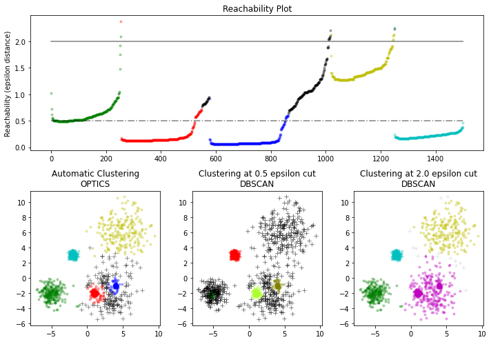

```python
plt.figure(figsize=(10, 7))
G = gridspec.GridSpec(2, 3)
ax1 = plt.subplot(G[0, :])
ax2 = plt.subplot(G[1, 0])
ax3 = plt.subplot(G[1, 1])
ax4 = plt.subplot(G[1, 2])

# Reachability plot
colors = ['g.', 'r.', 'b.', 'y.', 'c.']
for klass, color in zip(range(0, 5), colors):
    Xk = space[labels == klass]
    Rk = reachability[labels == klass]
    ax1.plot(Xk, Rk, color, alpha=0.3)

ax1.plot(space[labels == -1], reachability[labels == -1],
         'k.', alpha=0.3)
ax1.plot(space,               np.full_like(space, 2., dtype=float),
         'k-', alpha=0.5)
ax1.plot(space,               np.full_like(space, 0.5, dtype=float),
         'k-.', alpha=0.5)
ax1.set_ylabel('Reachability (epsilon distance)')
ax1.set_title('Reachability Plot')

# OPTICS
colors = ['g.', 'r.', 'b.', 'y.', 'c.']
for klass, color in zip(range(0, 5), colors):
    Xk = X[clust.labels_ == klass]

    ax2.plot(Xk[:, 0],
             Xk[:, 1], color, alpha=0.3)
    ax2.plot(X[clust.labels_ == -1, 0],
             X[clust.labels_ == -1, 1], 'k+', alpha=0.1)
ax2.set_title('Automatic Clustering\nOPTICS')

# DBSCAN at 0.5
colors = ['g', 'greenyellow', 'olive', 'r', 'b', 'c']
for klass, color in zip(range(0, 6), colors):
    Xk = X[labels_050 == klass]

    ax3.plot(Xk[:, 0],
             Xk[:, 1], color, alpha=0.3, marker='.')
    ax3.plot(X[labels_050 == -1, 0],
             X[labels_050 == -1, 1], 'k+', alpha=0.1)
ax3.set_title('Clustering at 0.5 epsilon cut\nDBSCAN')

# DBSCAN at 2.
colors = ['g.', 'm.', 'y.', 'c.']
for klass, color in zip(range(0, 4), colors):
    Xk = X[labels_200 == klass]

    ax4.plot(Xk[:, 0],
             Xk[:, 1], color, alpha=0.3)

ax4.plot(X[labels_200 == -1, 0],
         X[labels_200 == -1, 1], 'k+', alpha=0.1)
ax4.set_title('Clustering at 2.0 epsilon cut\nDBSCAN')

plt.tight_layout()
plt.show()
```

### Birch

- Builds a **Clustering Feature Tree (CFT)** with a set of *nodes*. Each node can have *subclusters*.
- CF subclusters hold enough info to preclude needing the entire dataset in memory.
- `threshold` limits the distance between the entering sample and existing subclusters.
- `branching` limits the number of subclusters in a node.
- Birch does not scale with high-dimension data. If `n_features`>20, consider using MiniBatchKmeans instead.

### [Birch vs MiniBatch Kmeans](https://scikit-learn.org/stable/auto_examples/cluster/plot_birch_vs_minibatchkmeans.html)

- Birch is run with & without global clustering, and Kmeans, on a synthetic dataset with 100K samples & 2 features.
- `n_clusters=None` reduces the dataset from 100K to 158 clusters. This is a preprocessing step before a global cluster step that further reduces them to 100 clusters.

```python
from itertools import cycle
from time import time
import numpy as np
import matplotlib.pyplot as plt
import matplotlib.colors as colors
from sklearn.cluster import Birch, MiniBatchKMeans as MBKM
from sklearn.datasets import make_blobs
```

```python
xx = np.linspace(-22, 22, 10)
yy = np.linspace(-22, 22, 10)
xx, yy = np.meshgrid(xx, yy)
n_centres = np.hstack((np.ravel(xx)[:, np.newaxis],
                       np.ravel(yy)[:, np.newaxis]))
X, y = make_blobs(n_samples=100000,
                  centers=n_centres,
                  random_state=0)
colors_ = cycle(colors.cnames.keys())
```

```
Birch without global clustering as the final step took 2.44 seconds
n_clusters : 158
Birch with global clustering as the final step took 2.36 seconds
n_clusters : 100
MiniBatchKMeans runtime: 2.50 seconds
```

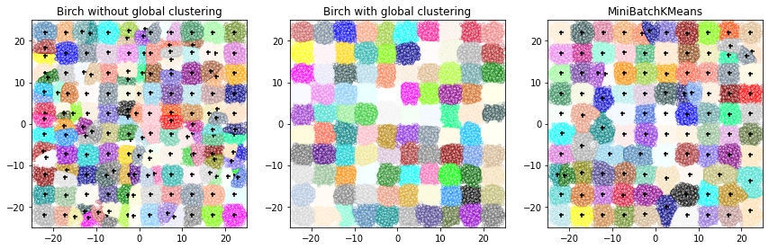

```python
fig = plt.figure(figsize=(12, 4))
fig.subplots_adjust(left=0.04, right=0.98, bottom=0.1, top=0.9)

birch_models = [Birch(threshold=1.7, n_clusters=None),
                Birch(threshold=1.7, n_clusters=100)]
final_step = ['without global clustering', 'with global clustering']

for ind, (birch_model, info) in enumerate(zip(birch_models, final_step)):

    t0 = time(); birch_model.fit(X); t1 = time() - t0
    print("Birch %s as the final step took %0.2f seconds" % (info, t1))

    # Plot result
    labels     = birch_model.labels_
    centroids  = birch_model.subcluster_centers_
    n_clusters = np.unique(labels).size

    print("n_clusters : %d" % n_clusters)

    ax = fig.add_subplot(1, 3, ind + 1)
    for this_centroid, k, col in zip(centroids, range(n_clusters), colors_):
        mask = labels == k
        ax.scatter(X[mask, 0], X[mask, 1],
                   c='w', edgecolor=col, marker='.', alpha=0.5)
        if birch_model.n_clusters is None:
            ax.scatter(this_centroid[0], this_centroid[1], marker='+',
                       c='k', s=25)
    ax.set_ylim([-25, 25])
    ax.set_xlim([-25, 25])
    ax.set_autoscaley_on(False)
    ax.set_title('Birch %s' % info)

mbk = MBKM(init='k-means++',
           n_clusters=100,
           batch_size=100,
           n_init=10,
           max_no_improvement=10,
           verbose=0,
           random_state=0)

t0 = time(); mbk.fit(X); t1 = time() - t0
print("MiniBatchKMeans runtime: %0.2f seconds" % t1)
mbk_means_labels_unique = np.unique(mbk.labels_)

ax = fig.add_subplot(1, 3, 3)
for this_centroid, k, col in zip(mbk.cluster_centers_,
                                 range(n_clusters), colors_):
    mask = mbk.labels_ == k
    ax.scatter(X[mask, 0], X[mask, 1], marker='.',
               c='w', edgecolor=col, alpha=0.5)
    ax.scatter(this_centroid[0], this_centroid[1], marker='+',
               c='k', s=25)
ax.set_xlim([-25, 25])
ax.set_ylim([-25, 25])
ax.set_title("MiniBatchKMeans")
ax.set_autoscaley_on(False)
plt.show()
```